# EDA

## Temperature from meteo swiss

```r
library(tidyverse)

#### Daten einlesen ####

# Engelberg
engelberg <- read.csv("Daten/Engelberg_data.csv", sep = ';', na.strings = c('-',''))

engelberg$time <- as.Date(as.character(engelberg$time), format = "%Y%m%d")
engelberg_clean <- engelberg %>% select('stn',
                                        'time',
                                        'tre200nn')

# Seeboden
seeboden <- read.csv("Daten/Seebodenalp_data.csv", sep = ';', na.strings = c('-',''))
# Convert integer dates to Date objects
seeboden$time <- as.Date(as.character(seeboden$time), format = "%Y%m%d")
seeboden_clean <- seeboden %>% select('stn',
                                      'time',
                                      'tre200nn')
```

**Engelberg**: inspection of the needed variables

```r
str(engelberg_clean)
```

```
## 'data.frame':    15737 obs. of  3 variables:
##  $ stn     : chr  "ENG" "ENG" "ENG" "ENG" ...
##  $ time    : Date, format: "1980-01-01" "1980-01-02" ...
##  $ tre200nn: num  -5.6 -6.8 -6.5 -9.8 1 -3.4 -1.4 -8.4 -12.6 -4.5 ...
```

```r
summary(engelberg_clean)
```

```
##      stn                 time               tre200nn
##  Length:15737       Min.   :1980-01-01   Min.   :-25.100
##  Class :character   1st Qu.:1990-10-09   1st Qu.: -1.500
##  Mode  :character   Median :2001-07-17   Median :  3.400
##                     Mean   :2001-07-17   Mean   :  3.079
##                     3rd Qu.:2012-04-24   3rd Qu.:  8.600
##                     Max.   :2023-01-31   Max.   : 21.400
##                                          NA's   :654
```

**Seeboden**: inspection of the needed variables

```r
# NA anschauen
str(seeboden_clean)
```

```
## 'data.frame':    11889 obs. of  3 variables:
##  $ stn     : chr  "NABRIG" "NABRIG" "NABRIG" "NABRIG" ...
##  $ time    : Date, format: "1991-06-14" "1991-06-15" ...
##  $ tre200nn: num  9.4 11.3 12.7 6.2 NA 5 6.2 8.3 13.7 13.2 ...
```

```r
summary(seeboden_clean)
```

```
##      stn                 time               tre200nn
##  Length:11889       Min.   :1991-06-14   Min.   :-20.10
##  Class :character   1st Qu.:1999-08-03   1st Qu.:  0.20
##  Mode  :character   Median :2007-09-22   Median :  5.50
##                     Mean   :2007-09-22   Mean   :  5.25
##                     3rd Qu.:2015-11-11   3rd Qu.: 10.60
##                     Max.   :2023-12-31   Max.   : 24.40
##                                          NA's   :119
```

### Visualizing

**tre200nn** = Lufttemperatur 2 m ¸ber Boden; Nachtminimum (18 UTC Vortag bis 6 UTC aktueller Tag)

```r
#### EDA ####
# Histogram
hist_engelberg <- ggplot(engelberg_clean, aes(x = tre200nn)) +
  geom_histogram(bins = 30, fill = "blue", color = "black") +
  labs(title = "Distribution of Engelberg Temperature", x = "Temperature", y = "Count")

hist_seeboden <- ggplot(seeboden_clean, aes(x = tre200nn)) +
  geom_histogram(bins = 30, fill = "orange", color = "black") +
  labs(title = "Distribution of Seebodenalp Temperature", x = "Temperature", y = "Count")

# Boxplot
boxplot_engelberg <- ggplot(engelberg_clean, aes(y = tre200nn)) +
  geom_boxplot(fill = "blue", color = "darkred") +
  labs(title = "Boxplot of Engelberg Temperature", y = "Temperature")

boxplot_seeboden <- ggplot(seeboden_clean, aes(y = tre200nn)) +
  geom_boxplot(fill = "orange", color = "darkred") +
  labs(title = "Boxplot of Seebodenalp Temperature", y = "Temperature")

# Timeseries
timeseries_engelberg <- ggplot(engelberg_clean, aes(x = time, y = tre200nn)) +
  geom_line() +
  labs(title = "Time Series of Engelberg Temperature", x = "Time", y = "Temperature")

timeseries_seeboden <- ggplot(seeboden_clean, aes(x = time, y = tre200nn)) +
  geom_line() +
  labs(title = "Time Series of Seebodenalp Temperature", x = "Time", y = "Temperature")
```

#### Histogram

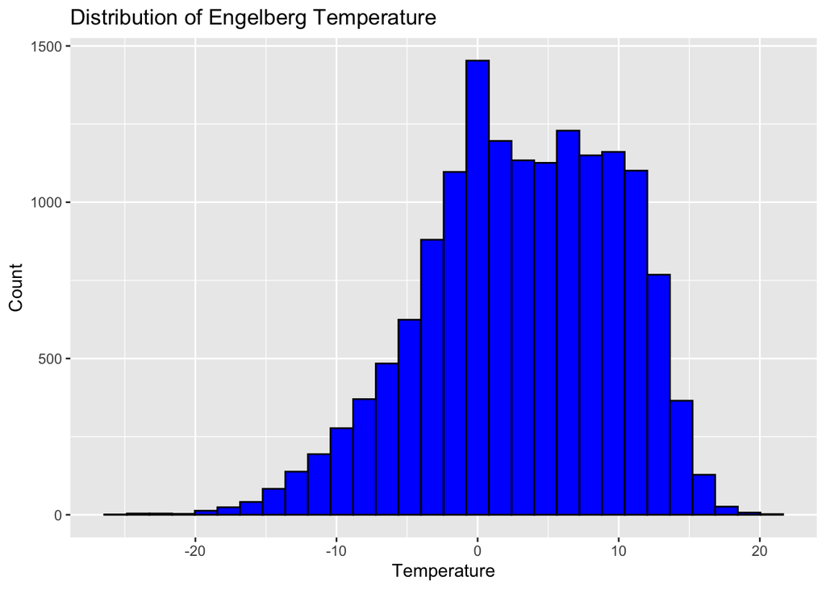

```r
hist_engelberg
```

This histogram shows the temperature distribution in Engelberg, with most occurrences between 0 and 5 degrees Celsius. The data spans a broad range from below -20 to above 20 degrees Celsius, showing significant variability in temperatures. The distribution appears slightly left-skewed, suggesting that lower temperatures are more frequent than higher ones.

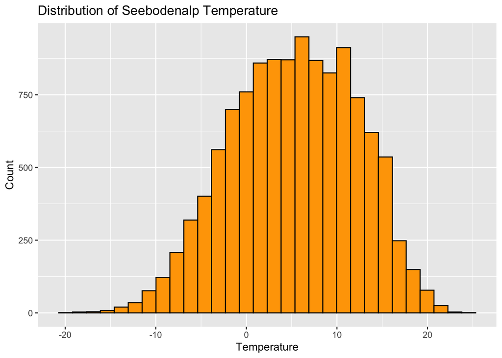

```r
hist_seeboden
```

This histogram displays the temperature distribution in Seebodenalp (Rigi), with a symmetric shape centered around 5 to 10 degrees Celsius, indicating a normal distribution pattern. The temperatures range from below -20 to above 20 degrees Celsius, with the highest frequency of occurrences in the previously mentioned central range.